# Analysis of Environmental Data - Using Models 2

Sarah Guitart

Collaborating Students: None

### Q1

*Re-create the conditional boxplot of penguin body mass conditioned on sex and species. Include your boxplot as a figure in your report.*

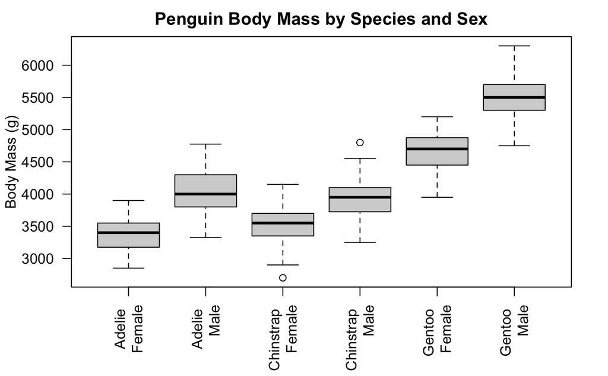

```r
require(palmerpenguins)
boxplot(body_mass_g ~ sex * species, data = penguins,
                      ylab = "Body Mass (g)", xlab = "", las = 2,
                    names = c("Adelie \n Female", "Adelie \n Male",
                                "Chinstrap \n Female", "Chinstrap \n Male",
                                "Gentoo \n Female", "Gentoo \n Male"),
                      main = "Penguin Body Mass by Species and Sex")
```

### Q3

*Do you think adding sex to a model that already includes species will improve the model fit?*

A: I think adding a model that already includes species will improve the model fit. This is because exploring the data through the boxplots with this additional parameter showed differences between groups that may assist with our ability to predict and interpret penguin weights.

### Q4

*Show the R-code you used to build fit_both.*

```r
fit_both <- lm(body_mass_g ~ sex * species, data = penguins)
```

### Q5

*What is the base case for the two-way model that includes sex and species?*

```r
summary(fit_both)
```

```
Call:
lm(formula = body_mass_g ~ sex * species, data = penguins)

Residuals:
    Min      1Q  Median      3Q     Max
-827.21 -213.97   11.03  206.51  861.03

Coefficients:
                         Estimate Std. Error t value Pr(>|t|)
(Intercept)               3368.84      36.21  93.030  < 2e-16 ***
sexmale                    674.66      51.21  13.174  < 2e-16 ***
speciesChinstrap           158.37      64.24   2.465  0.01420 *
speciesGentoo             1310.91      54.42  24.088  < 2e-16 ***
sexmale:speciesChinstrap  -262.89      90.85  -2.894  0.00406 **
sexmale:speciesGentoo      130.44      76.44   1.706  0.08886 .
---
Signif. codes:  0 ‘***’ 0.001 ‘**’ 0.01 ‘*’ 0.05 ‘.’ 0.1 ‘ ’ 1

Residual standard error: 309.4 on 327 degrees of freedom
  (11 observations deleted due to missingness)
Multiple R-squared:  0.8546,    Adjusted R-squared:  0.8524
F-statistic: 384.3 on 5 and 327 DF,  p-value: < 2.2e-16
```

A: The base case for this model are female Adelie penguins.

### Q6

*What are the names of the two coefficients (from the first column of the coefficient table) that you need to calculate the average mass of female Chinstrap penguins?*

A: The names of the two coefficients that I need to calculate the average mass of female Chinstraps penguins are “Intercept” and “speciesChinstrap.”

### Q7

*What is the predicted average mass of female Chinstrap penguins in the interactive model?*

A: The predicted average mass of female Chinstrap penguins from the interactive model is 3527.21 grams.

### Q8

*What is the observed average mass of female Chinstrap penguins, calculated from the penguins data?*

```r
aggregate(body_mass_g ~ sex * species, data = penguins, FUN = mean)
```

| sex | species | body_mass_g |
| --- | --- | --- |
| female | Adelie | 3368.836 |
| male | Adelie | 4043.493 |
| female | Chinstrap | 3527.206 |
| male | Chinstrap | 3938.971 |
| female | Gentoo | 4679.741 |
| male | Gentoo | 5484.836 |

A: The average mass of a female Chinstrap penguin from the penguin data is 3527.21 grams.